**TAIGA**

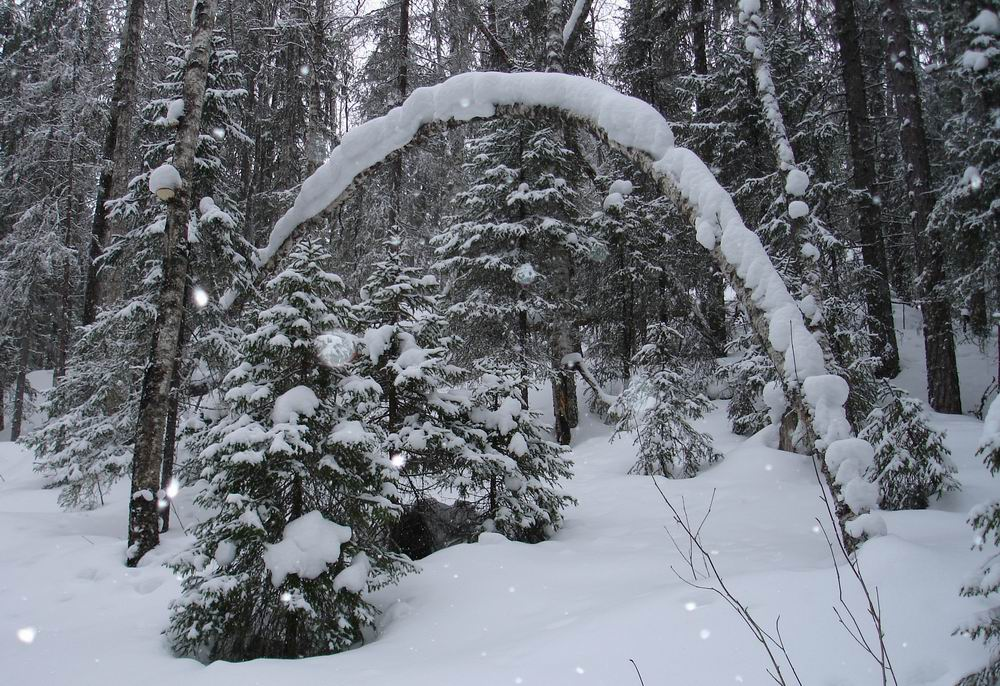

This software is made to find degenerate CRISPR-CAS9 gRNA targets in genome. It was developed a software to test different modificated Cas9 types.  
**Software requirements:**  
*Linux system* (tested in Ubuntu 16.04, kernel version 4.15.0-30-generic, 64 cores, 1TB RAM)  
*Multicore* (8+)  
*Ncbi-blast+* (install - sudo apt-get install ncbi-blast+ on Ubuntu/Debian systems)  
*R language* (install - sudo apt-get install r-base-core Rscript)  
*blastxmlparser* (install - sudo apt-get install ruby ruby-dev; sudu apt-get install gem; sudo gem install blastxmlparser)  
*RNAfold* (install - sudo apt-add-repository ppa:j-4/vienna-rna; sudo apt-get update; sudo apt-get install vienna-rna)  
*ssconvert* (optional, converts csv file to xls, install - sudo apt-get install gnumeric)  
*gffread* (need to convert genome file to CDS sequences) - see https://github.com/gpertea/gffread to install and compile. Gffread must be accessible from command prompt ()

**R packages: (will be installed automatically, by run install.R)**  
*Biostrings*  
*rtracklayer*  
*stringr*  
*parallel*  
*plyr*  
*dplyr*

**Run options** -g - genome file in FASTA file, file  
-a - annotation file in GTF format, file  
-s - length of a spacer sequence exclude PAM site (20, by default), integer  
-u - sequence that not allowed in spacer sequence (TTT, by default), string  
-p - PAM sequence, that unallowed (AA, by default), string  
-t - threads number, integer  
-w - size of the word in blast, integer (10 by default, **for debugging purposes only**)  
-d - uses only first 10 PAM sequences (T/F), bool  
-pr - prefix for output csv file (string, date by default)  
-sm - number of mismatches in seed region, integer (2 by default)  
-nm - number of mismatches in non-seed region, integer (4 by default)  
-tg - test specific gRNA sequence to find targets (GATTATAATATTCCTTGTGTTAG, for example), string  
-pc - use only protein-coding sequences, ignore intergenic region (T/F), bool  
-ts - test specific gene to find gRNA for its sequence (gene identifyer format should be  
from “gene_id” column from gtf) (**NOW UNDER DEVELOPMENT**), character  
-o - search for paralogs for gene (T/F) - works with -ts option, script will try to find paralogs for gene specifyed in -ts option (**NOW UNDER DEVELOPMENT, SHOULD BE ALWAYS FALSE**)  
-c - paralogs cutoff (evalue scoring cutoff for paralogs blast) - float, 0.05 by default (should be set greater then 0.05, if you cannot find paralogs in paralog search mode) (**NOW UNDER DEVELOPMENT**)

**Minimum required arguments** -g - genome file in FASTA file, file  
-t - number of threads, file  
-a - annotation file in GTF format, file  
-pc - use only protein-coding sequences, ignore intergenic region (T/F), bool  
-o - search for paralogs for gene (T/F) -d - debug mode (T/F)

**Sample runs:**  
*git clone https://github.com/aprezvykh/taiga**  
install.R* (don’t run it by sudo!)

**Sample runs:**  
Output of this script in genome-wide mode is presented with several files:  
1) prefix-graphic-report.pdf  
2) test1-results.csv (full table in CSV format, useful for analysis in R/Python)  
3) test1-output.html (full table in HTML format)  
4) test1top20-cutted-results.xls (top-20 gRNAs)  
5) test1top50-cutted-results.xls (top-50 gRNAs)  
6) test1top200-cutted-results.xls (top-200 gRNAs)

Output of this script in single gRNA-testing mode:  
prefix-single-gRNA.xlsx  
___

Column names explained:  
1) gRNA.id - id of guide RNA found  
2) gRNA.alignment.length - length of aligned guide RNA sequence  
3) bitscore - Bitscore parametr from blastn software  
4) evalue - Evalue parametr from blastn software  
5) Aligned.sequence - aligned part of guide RNA  
6) cigar.string - string; showing matches and mismatches of currend guide RNA, length 23 by default (| means match, X means mismatch)  
7) total.mismatch.N - total number of mismatches in alignment  
8) mismatch.position - position of mismatch (from left to right)  
9) validation - shows alignment validation (from mismatch number in seed and non-seed region)  
10) Locus - shows position of guide RNA alignment (gene_id or intergenic)  
11) gRNA.Energy - free fold energy of guide RNA  
12) GC.content - GC content :)  
13) Genomic.coordinate - genomic coordinate in alignment  
___

If you found an issue, please, report it in current repository or email me:  
*aprezvykh@yandex. ru*